# mecha

Contents:

- Welcome to Mecha
- An Example
  - Workflow: import mechanisms, setup a simulator, run!
  - Behind the Example
    - The structure of a Mecha model
    - Param trio: init_val, update_val, update_when
    - Two kinds of params
    - Two ways to change param values
      - Changing param values with rules: The sir mechanism
      - Changing param values by updating - The seasons mechanism
- Mecha Package API
  - Parameters
    - Param Methods : reset and rebuild ###
    - Param Methods : update ###
    - Special Param Attributes and Methods
      - Array
      - Cohort
      - Column
      - Counter
      - Cycle
      - MultiColumn
      - Multinomial
      - Probs
      - Simplex
      - Switch
    - Passing parameters to lambda expressions and functions in Params ###
  - Rules
    - How Rules work
    - Rule Attributes and Methods
    - Rule Methods
  - Decisions
    - Simplexes
      - Simplex methods -- Update
      - Simplex methods -- Sample
    - Influences
  - Mechanisms
    - Mechanism methods
    - Working with multiple mechanisms
  - Simulators

# Welcome to Mecha

### Paul Cohen

Mecha is a package for building probabilistic simulations, including agent-based simulations. Mecha supports teams of modelers building "nearly independent" mechanisms that run in simulations. This document begins with an example involving two mechanisms, one that simulates the progression of seasons, another that simulates epidemics. They are nearly independent except that infection rates in epidemics depend on the season. This is an asymmetric dependency between mechanisms: The epidemic mechanism depends on season but not vice versa. `Mecha` also supports symmetric dependencies, allowing teams to work on nearly-independent mechanisms without worrying about circular import problems.

# An Example

We begin with an example of two independently created mechanisms called `seasons` and `sir`. Their tasks are to model the progression of seasons and the dynamics of an epidemic. They will be linked together through a single param and run as a simulation. We will define terms like param, mechanism and simulation later.

First, tell Jupyter where to find your installation of the `Mecha` package and import it:

```python
import os
os.chdir("/Users/prcohen/Pitt/Code/Mechanisms")
import mecha
```

Next, import two modules and name them `seas` and `covid` (we'll look at them later) and then bind the mechanisms they contain to the variables `sir` and `seasons`. Finally, examine `seasons`:

```python
import mecha.mechanisms.seasons as seas
import mecha.mechanisms.covid as covid

sir = covid.sir
seasons = seas.seasons

seasons
```

```
namespace(name='seasons',
          n=None,
          type='Mechanism',
          objects=OrderedDict([('clock',
                                <mecha.classes.param_classes.Cycle at 0x7f9975ba1050>),
                               ('dagana_season_transition_days',
                                <mecha.classes.param_classes.Param at 0x7f9975ba1350>),
                               ('season',
                                <mecha.classes.param_classes.Cycle at 0x7f9975ba1390>)]),
          rules=[],
          clock=<mecha.classes.param_classes.Cycle at 0x7f9975ba1050>,
          dagana_season_transition_days=<mecha.classes.param_classes.Param at 0x7f9975ba1350>,
          season=<mecha.classes.param_classes.Cycle at 0x7f9975ba1390>)
```

This shows us that `seasons` is an instance of the class `Mechanism` and it includes three objects: `clock` is a `Cycle` param, `dagana_season_transition_days` is a `Param` param, and `season` is a `Cycle` param. The `sir` mechanism is a bit more complicated:

```python
sir.describe()
```

```
Mechanism sir
n = 100000
objects =
  beta:  <mecha.classes.param_classes.Param object at 0x7f9975ba1cd0>
  gamma:  <mecha.classes.param_classes.Probs object at 0x7f9975ba1d10>
  health:  <mecha.classes.param_classes.Column object at 0x7f9972214690>
  susceptible:  <mecha.classes.param_classes.Cohort object at 0x7f9974d6ca90>
  infected:  <mecha.classes.param_classes.Cohort object at 0x7f9975ba1d50>
  recovered:  <mecha.classes.param_classes.Cohort object at 0x7f9975ba1dd0>
  anon_101:  <mecha.classes.param_classes.Probs object at 0x7f9975ba1e10>
  s2i:  <mecha.classes.rule_classes.Rule object at 0x7f9975ba1d90>
  i2r:  <mecha.classes.rule_classes.Rule object at 0x7f9975ba95d0>
  anon_102:  <mecha.classes.param_classes.Multinomial object at 0x7f99743cd0d0>
```

Note that `sir` has a "size", denoted `n`, of 100000. This is the size of the population in which the epidemic operates. `sir` has several kinds of params, including `Cohort`s such as susceptible, infected and recovered individuals; a `Column` called `health` that records the health status of individuals; a couple of `Probs` objects that contain probabilities; and two `Rule`s.

## Workflow: import mechanisms, setup a simulator, run!

We have already imported two mechanisms, but for the sake of completeness we'll do it again to illustrate a common workflow: Import mechanisms, set up initial conditions, define a simulator, run it and analyze the results:

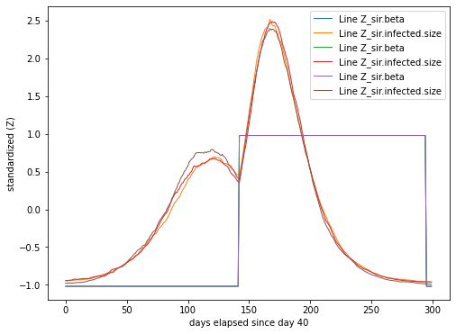

```python
# import the classes needed to run a simulation
from mecha.classes.mechanism_classes import MechMap, Sim

# import the classes needed to plot results
from mecha.classes.utils import plot_series, plot_multiseries,plot_replicates

# pandas is used to manipulate data from the simulation but if you don't want to
# use it, then you can find all the results in sim.record.
import pandas as pd

# mechanisms are defined in Python modules. Import them.
import mecha.mechanisms.seasons as seas
import mecha.mechanisms.covid as covid

# name the mechanisms contained in the modules
sir = covid.sir
seasons = seas.seasons

# define initial conditions

def setup_sir ():
    # if no-one in the population is infected then the epidemic cannot spread
    # set the health status of the first 50 individuals to 1, which means infected
    sir.health.val[0:50] = 1

def setup_seas ():
    # the current season depends on the current date
    # seas.starting_season maps the current date to a season label
    seasons.start_label = seas.starting_season()

# define the information we want to collect during the simulation

def probe_fn ():
    return [sir.s2i.multinomial.probs.val,sir.infected.size,seasons.season.curr,sir.beta.val]

probe_labels = ['p','sir.infected.size','seasons.season','sir.beta']

# set up a simulator that will run three replicates (trials) each of 300 days duration
# the setup field tells the simulator which mechanisms to use and which functions define
# initial conditions for these mechanisms.  The probe_fn and probe_labels tell the simulator
# which information to gather

sim = Sim(
    n_trials = 3,
    n_steps = 300,
    setup = [(sir, setup_sir),(seasons, setup_seas)],
    probe_fn = probe_fn,
    probe_labels = probe_labels
    )

# One last step:  The mechanisms themselves have not been "initialized".
# The need for initialization is discussed in the section on importing multiple mechanisms

sir.initialize()
seasons.initialize()

# Run the simulation and visualize the results.
# The sim runs fast but the plotting takes a few seconds; be patient.

sim.run()

df = pd.DataFrame(sim.record,columns=['trial','step']+probe_labels)
df1 = df[['sir.beta','step','trial','sir.infected.size']]
plot_replicates(df1,x='step',standardize=True,xlabel=f"days elapsed since day {seasons.clock.initargs.get('init_val')}",ylabel='standardized (Z)')
```

You should see three curves that represent the standardized size of the infected cohort of the population, and three lines that overlay each other perfectly that represent the standardized infection rate. The infected cohort grows slowly, peaking roughly 100 days into the simulation. But around day 140, the season changes and with it the infection rate, producing a more aggressive "second wave" of infections.

## Behind the Example

In this section, we will expose the params, rules and mechanisms behind the preceding example, though formal APIs for these objects are deferred until Section API.

### The structure of a Mecha model

Applications in the `Mecha` package have a simple, hierarchical structure:

- Lowest level: Params, Rules and functions
- Middle level: Mechanisms composed from Params and Rules
- Highest level: Simulations composed from Mechanisms

To help developers see the structure of a `Mecha` model, the `MechMap` class creates a "map" of all the objects in a simulation and presents it as a graph:

```python
d,g = MechMap.make(sir,seasons,viz=True)
display(g)
```

[figure not shown]

Each node in this graph represents a param or a rule. Node names have prefixes that indicate which mechanism they belong to; for example, `sir.health` is a param called `health` in mechanism `sir`. The arcs represent kinds of dependencies between objects. For example, `health` is involved in setting the initial value and updating the value (`init_val` and `update_val`, respectively) of three Cohort objects, `sir.susceptible`,`sir.infected` and `sir.recovered`. This makes sense: these cohorts are defined by the health of their members.

`sir.s2i` is a Rule object that makes some susceptible people sick, or infected. Thus it is related to `sir.susceptible` by the `cohort` relationship; it acts on members of that cohort. The actions themselves are specified by the rule's `actionlists`. The rule `s2i` has `sir.health` in its actionlists, meaning that it acts on the `sir.health` attribute of its cohort. Similarly, the rule `i2r`, which makes some infected people recover, also acts on `health`, but its cohort is infected people, namely `sir.infected`. Both rules are probabilistic in ways we'll explain later; suffice it to say that each requires probabilistic params. These are represented by `probs` and `multinomial` arcs; for example, `sir.s2i` depends on two "anonymous" probabilities.

On the left is the `seasons` mechanism. Two params control when `seasons.season` is updated (i.e., `seasons.season` has two `update_when` dependencies). `seasons.clock` keeps track of the day of the year and `seasons.dagana_season_transition_days` is a list of days of the year on which agricultural seasons change in the Dagana region of the Senegal River Valley.

Note that `seasons.season` affects both the initial value and the update value of `sir.beta`, which is the param that controls the infection rate in the `sir` mechanism. Clearly, the `seasons` and `sir` mechanisms are "nearly independent" except for these two dependencies between `sir.beta` and `seasons.season.` Dependencies between mechanisms are discussed in the section on working with multiple mechanisms.

**TODO** There should be a link between sir.beta and sir.anon_103. MechMap doesn't know this because the connection between them is mediated by a function (p_transmission). MechMap doesn't read functions, only params and rules, so it doesn't know that p_transmission connects sir.beta with sir.anon_103. The solution is to have MechMap read functions, but a lot of functions in a module have nothing to do with the mechanism (e.g., functions for plotting results). It's easy to define a function decorator for "mechanism functions" to distinguish them from others, I just need to do this and add some code to MechMap. That said, MechMap's code for finding dependencies is pretty crufty and could use a rethink.

### Param trio: init_val, update_val, update_when

In subsequent code blocks you will see that nearly all params have an `init_val`, some have an `update_val` and some have an `update_when`. These control how params initialize and update their values.

Updating happens only when `update_when` evaluates to `True`. `update_when` can be callable so dynamic conditions can dictate when to update. One way to disable updating a param (e.g., in an ablation experiment) is to set `update_when` to `False`.

Both `init_val` and `update_val` may be values or callables. The initial value of a param can be set by a different method than subsequent values; e.g., initial value might be a constant whereas `update_val` might be a callable that depends on dynamic conditions.

### Two kinds of params

Some mechanisms, such as the `sir` compartmental model, operate on "populations". The underlying params are one- or two-dimensional with one dimension representing "individuals" in the population. By convention, the number of individuals is called `n` and for two-dimensional params the other dimension is called `m`. (The `Mecha` package also includes params with more than two dimensions, such as Simplexes, discussed later.) Note that different mechanisms can have different populations; for example, one mechanism can represent all the farmers in a region, another might represent all the banks that supply credit to the farmers.

The param classes that represent populations are `Column, MultiColumn, Cohort, Multinomial`, and `Simplex`.

Another kind of param represents the state of a mechanism but not any particular individual. For example, the probability of recovering from a viral infection *could* be an attribute of individuals (i.e., each individual has its own probability) but in simple compartmental models this probability is a global state variable. Similarly, the current season is a state variable, not an individual one.

The param classes that represent mechanism state variables are `Probs, Counter, Switch`, and `Cycle`.

To illustrate, here are the param definitions for the `sir` mechanism:

```python
from mecha.classes.rule_classes import Rule
from mecha.classes.param_classes import Param, Cohort, Probs, Column

import mecha.classes.rule_classes as rule_classes
import mecha.classes.param_classes as pc

# health is a Column param (a one-dimensional numpy array). If the
# length of a Column is not specified, it is assumed to be the value
# of sir.n, the population size of sir.

# Each row contains a value, though initially the Column is entirely zeros
# (i.e., init_val = 0).  In this model, 0, 1 and 2 will denote susceptible,
# infected and recovered, respectively.

health = Column(name = 'health',
                mechanism = sir,
                init_val = 0)

# Note that param objects can be bound to variables for later use.

# susceptible, infected and recovered\ are Cohort params.  Cohorts are
# boolean Columns (i.e, columns of True and False).  The init_val and update_val
# for Cohorts typically are functions that test something and return True or False.
# For example, for the susceptible cohort, the function - a lambda expression --
# returns True wherever health == 0.

S = Cohort(
    name = 'susceptible',
    mechanism = sir,
    init_val = lambda self: health.eq(0),  # True wherever health == 0
    update_val = lambda self: health.eq(0))


I = Cohort(
    name = 'infected',
    mechanism = sir,
    init_val = lambda self: health.eq(1), # True wherever health == 1
    update_val = lambda self: health.eq(1))

R = Cohort(
    name = 'recovered',
    mechanism = sir,
    init_val = lambda self: health.eq(2), # True wherever health == 2
    update_val = lambda self: health.eq(2))


# gamma is a Probs param so its init_val must be a list or array
# of numbers that sum to 1.0, otherwise the param will throw an error
# gamma represents the probability of recovering from illness on each day

Probs(name='gamma',
      mechanism = sir,
      init_val = [.1,.9])

# beta controls infectivity.  It depends on season. The dict beta_for_season
# gives the beta value for each season

beta_for_season = {'fallow' : .15,'ssc' : .15,'hiv' : .3, 'ssf' : .3}

# the season labels (e.g., 'fallow') come from a different mechanism, namely the
# seasons mechanism. The value of seasons.season can be gotten from a "Registry",
# which is described later, along with the cryptic init_now = False.

beta = Param(
    init_now=False,
    name='beta',
    mechanism = sir,
    init_val = lambda self: beta_for_season[Registry.get('seasons','season').val],
    update_val = lambda self: beta_for_season[Registry.get('seasons','season').val]
    )


print("\nMechanism objects issue warnings whenever their consituents objects are redefined. Ignore them, here.")
```

```
WARNING:  Overwriting parameter health
WARNING:  Overwriting parameter susceptible
WARNING:  Overwriting parameter infected
WARNING:  Overwriting parameter recovered
WARNING:  Overwriting parameter gamma
WARNING:  Overwriting parameter beta

Mechanism objects issue warnings whenever their consituents objects are redefined. Ignore them, here.
```

### Two ways to change param values

The `Mecha` package provides two ways to implement dynamics. `Rules` can probabilistically change attributes of entire populations (e.g., probabilistically spread infections), and `Params` can be updated. Most of the changes in the `sir` mechanism are caused by rules, all of the changes in the `seasons` mechanism result from param updating.

#### Changing param values with rules: The sir mechanism

The following code block specifies the rules in the `sir` mechanism. First, to keep the example simple, we write a version of the `beta` parameter that doesn't depend on the `seasons` mechanism (see here for more about dependencies between mechanisms). The we define a function, `p_transmission`, that is used in the `s2i` rule. The function calculates the probability that a susceptible member of the population becomes infected in the next time step. The definition of `s2i` follows. It applies to a cohort S (susceptible) and it has two actionlists. The first changes the value of the `health` column to 1. The second actionlist is empty, which is the `Mecha` convention for "do nothing".

Because `s2i` has two actionlists, we need to specify the probability of applying each to the susceptible cohort. This is the job of the `probs` param in the `s2i` definition. `probs` is bound to a `Probs` param that itself refers to the probability of transmission. In effect, it says that the probability of the first actionlist applying (and thus, the complement probability of the "do nothing" actionlist applying) is a function of the probability of transmission. Please read about how rules work before you start to write your own rules.

In short, the `s2i` rule changes the `health` param value to 1 (i.e., infected) for selected members of the `susceptible` (S) cohort and leaves the rest of the cohort untouched. The selection is controlled by the probability in the `probs` attribute.

The `i2r` rule behaves similarly: Its cohort is the infected members of the population. It selects some of these according to `probs`, which in this case is set to the `gamma` param, defined earlier. Functionally, it changes selected rows of the `health` column to have the value 2, which is the criterion for the `recovered` cohort.

```python
# redefine beta (for this example only) so it doesn't depend on seasons

beta = Param(name='beta',mechanism = sir, init_val = .18, update_val = .18)

# define a function that calculates the probability that a population
# member will become infected on the next time step

def p_transmission ():
    n = sir.n

    # The probability of being an infectious agent is:
    p_infectious = sir.infected.size / n

    # Similarly, the probability of being a Susceptible agent is:
    p_susceptible = sir.susceptible.size / n

    # The probability that one meeting between two agents has one
    # infectious and one Susceptible is:
    p_one_potential_transmission = p_infectious * p_susceptible

    # Potential transmissions become actual transmissions with
    # probability beta:
    p_one_transmission = p_one_potential_transmission * sir.beta.val

    # return both probability of transmission and its complement
    return [p_one_transmission, 1 - p_one_transmission]


# This Rule creates new infections. It pertains only to the susceptible
# Cohort (otherwise it would cause infections among population members who are
# already infected or recovered).  It has two actionlists.  The first sets
# the value of health to 1, the second is empty: It's the "do nothing" action.
# The probabilities of these two actions are given by probs.

# Ignore init_now = False for now

s2i = Rule(
    name = 's2i',
    mechanism = sir,
    cohort = S,
    actionlists = [ [(health,1)],[] ],
    probs = Probs(
        init_val = lambda self: p_transmission(),
        update_val = lambda self: p_transmission()
        ))

# This rule applies to the infected Cohort. It transforms some infected
# cohort members into recovered cohort members. It has two actions, one
# of which sets the value of health to 2 (i.e., recovered), the other
# is the "do nothing" action.  Which of these happens is determined
# by probs, which is the gamma param defined earlier.

i2r = Rule(
    name = 'i2r',
    mechanism = sir,
    cohort = I,
    actionlists = [ [(health,2)],[] ],
    # 10% of infected recover on each time step
    probs = sir.gamma
    )
```

```
WARNING:  Overwriting parameter beta
WARNING:  Overwriting parameter s2i
WARNING:  Overwriting parameter i2r
```

We can run these rules by creating a simulator, but it is instructive to write a little code to do it. When the code runs you will see the characteristic exponential growth in the size of the infected cohort. (If you don't see it, re-run the previous notebook cells.)

```python
# Reset health (in case you want to run this repeatedly)
health.reset()

# Set initial conditions: Some of the population must be infected otherwise none can be infected!
# Say the first 50 members of the population are infected.  Then update the cohorts.

health.val[:50] = 1
for cohort in [S,I,R]: cohort.update()
print(f"Initial cohorts and sizes\nsusceptible: {S.size}, infected: {I.size}, recovered: {R.size}\n")


print("susceptible  infected  recovered")
print(f"{S.size:8} {I.size:10} {R.size:10}")
# run 30 timesteps
for i in range(30):
    s2i.run_rule()
    i2r.run_rule()

    # recalculate the probability of transmission, which will have changed
    # because more people have become infected
    s2i.probs.update()
    # recalculate the multinomial probabilities, which depend on p_transmission
    s2i.multinomial.update()

    # update the cohorts
    for cohort in [S,I,R]: cohort.update()
    print(f"{S.size:8} {I.size:10} {R.size:10}")
```

```
Initial cohorts and sizes
susceptible: 99950, infected: 50, recovered: 0

susceptible  infected  recovered
   99950         50          0
   99950         44          6
   99942         52          6
   99932         60          8
   99922         67         11
   99905         83         12
   99895         92         13
   99873        114         13
   99859        126         15
   99834        151         15
   99809        173         18
```

[output cut: 20 more lines]

#### Changing param values by updating - The seasons mechanism

Rules are one way to change param values, the other is through param `update_val` and `update_when` methods. In fact, you can build a simulator without any rules by relying on these methods, alone. To illustrate, we'll review the `seasons` mechanism. The following code defines three params and then runs 200 "days," printing the day and season. `Cycle` params update themselves whenever their `update_when` attribute evaluates to `True`, which is the default value for `Cycle` params. Thus, the `clock` cycle updates on every time step but the `season` param updates only when the clock hits one of the specified `dagana_season_transition_days`.

```python
from mecha.classes.mechanism_classes import Mechanism, Sim
from mecha.classes.rule_classes import Rule
from mecha.classes.param_classes import Param, Probs, Counter, Cycle


seasons = Mechanism('seasons')
current_mechanism = seasons

# In the Dagana region of the Senegal River Valley, the cropping seasons change on
# the days of the year specified here
Param(
    name = 'dagana_season_transition_days',
    mechanism = seasons,
    init_val = [32, 182, 288, 335],
    doc = '''This stores the days on which agricultural seasons change.
    Different parts of the country will have different transition days.'''
    )

# Cycles are params whose values change in a fixed order, then reset
# This one cycles through the days of the year
Cycle(
      name = 'clock',
      mechanism = seasons,
      labels = [i for i in range(1,366)],
      init_val = 200,
      update_val = True,
      doc = '''This cycles through the seasons.'''
    )

# We will cycle through cropping seasons as well, but we need a function
# to "read" the clock and tell which cropping season we're starting in

def starting_season ():
    '''Returns the starting state of the season Cycle based on the clock value.'''
    c = seasons.clock.val
    d = seasons.dagana_season_transition_days.val
    if c < d[0] or c >= d[3]: return 'fallow'
    if c < d[1]: return 'ssc' # "saison sec chaude"
    if c < d[2]: return 'hiv' # "hivernage" or wet season
    if c < d[3]: return 'ssf' # "saison sec froid"

# This Cycle param cycles through the seasons, updating when the clock
# reaches one of the season transition days

season = Cycle(
      name = 'season',
      mechanism = seasons,
      labels = ['fallow','ssc','hiv','ssf'],
      init_val = starting_season(),
      update_when = lambda self: seasons.clock.curr in seasons.dagana_season_transition_days.val,
      doc = '''This cycles through the seasons'''
    )


# test
for i in range(200):
    seasons.clock.update()
    seasons.season.update()
    print(f"day:   {seasons.clock.val:5}     season: {seasons.season.curr:12} last season:  {seasons.season.prev:20}")
```

```
WARNING: Overwriting mechanism seasons in Registry.
day:     201     season: hiv          last season:  ssc
day:     202     season: hiv          last season:  ssc
day:     203     season: hiv          last season:  ssc
day:     204     season: hiv          last season:  ssc
day:     205     season: hiv          last season:  ssc
day:     206     season: hiv          last season:  ssc
day:     207     season: hiv          last season:  ssc
day:     208     season: hiv          last season:  ssc
day:     209     season: hiv          last season:  ssc
day:     210     season: hiv          last season:  ssc
day:     211     season: hiv          last season:  ssc
day:     212     season: hiv          last season:  ssc
day:     213     season: hiv          last season:  ssc
day:     214     season: hiv          last season:  ssc
day:     215     season: hiv          last season:  ssc
day:     216     season: hiv          last season:  ssc
day:     217     season: hiv          last season:  ssc
day:     218     season: hiv          last season:  ssc
day:     219     season: hiv          last season:  ssc
day:     220     season: hiv          last season:  ssc
day:     221     season: hiv          last season:  ssc
day:     222     season: hiv          last season:  ssc
day:     223     season: hiv          last season:  ssc
day:     224     season: hiv          last season:  ssc
day:     225     season: hiv          last season:  ssc
day:     226     season: hiv          last season:  ssc
day:     227     season: hiv          last season:  ssc
day:     228     season: hiv          last season:  ssc
day:     229     season: hiv          last season:  ssc
day:     230     season: hiv          last season:  ssc
day:     231     season: hiv          last season:  ssc
day:     232     season: hiv          last season:  ssc
day:     233     season: hiv          last season:  ssc
day:     234     season: hiv          last season:  ssc
day:     235     season: hiv          last season:  ssc
day:     236     season: hiv          last season:  ssc
day:     237     season: hiv          last season:  ssc
day:     238     season: hiv          last season:  ssc
day:     239     season: hiv          last season:  ssc
```

[output cut: 146 more lines]

```
day:      21     season: fallow       last season:  ssf
day:      22     season: fallow       last season:  ssf
day:      23     season: fallow       last season:  ssf
day:      24     season: fallow       last season:  ssf
day:      25     season: fallow       last season:  ssf
day:      26     season: fallow       last season:  ssf
day:      27     season: fallow       last season:  ssf
day:      28     season: fallow       last season:  ssf
day:      29     season: fallow       last season:  ssf
day:      30     season: fallow       last season:  ssf
day:      31     season: fallow       last season:  ssf
day:      32     season: ssc          last season:  fallow
day:      33     season: ssc          last season:  fallow
day:      34     season: ssc          last season:  fallow
day:      35     season: ssc          last season:  fallow
```

# Mecha Package API

## Parameters

Params hold and update *values*, the types of which must be integer, float, boolean or Numpy arrays of integers, floats or booleans.

The Mecha package has 11 param classes, illustrated below. At the implementation level, all but one are Numpy arrays, but as modeling constructs they have quite different interpretations. Columns, Cohorts, and Multinomials all are intended to represent attributes of a population. They are one-dimensional arrays where each entry represents one member of the population. MultiColumns and Simplexes are two-dimensional: the rows represent population members and the columns are semantically related. The Array class is just a wrapper around Numpy 2D arrays. The Probs, Counter, Switch, and Cycle classes do not individuate members of a population but rather represent aspects of a Mechanism's state.

| Parameter Class | Description |
| --- | --- |
| **Param** | The class of which other Params are subclasses |
| **Array** | A wrapper around Numpy arrays whose API matches that of the other param classes |
| **Cohort** | A boolean vector in which True means "member of the cohort". |
| **Column** | An vector of length n, which is usually the "population size". Different mechanisms can have different populations. |
| **Counter** | A param that begins at a value and increases by an increment. |
| **Cycle** | A param whose value is one of a ring of values, such as fall, winter, spring, summer. |
| **MultiColumn** | A 2D param in which each column is a different "version" of the same thing; for example, profit_by_quarter might be a MultiColumn whose columns represent the 1st, 2nd, 3rd and 4th quarter of the year |
| **Multinomial** | A column that contains a multinomial distribution generated from Probs |
| **Probs** | A class whose value is a vector of numbers that sum to 1.0 |
| **Switch** | A param that can be in one of k states depending on which of k conditions is true. |
| **Simplex** | A param that holds vectors of values that sum to 1.0, such as `[0.2, 0.1, 0.3, 0.15, 0.25]`. These vectors must have the same length. |

All params have the following attributes, most of which have default values:

| Attribute | Explanation |
| --- | --- |
| **name** = None | If a name is not specified, then the param is "anonymous" and will be given a unique name that begins with `anon`. |
| **mechanism**=None | The name of the mechanism to which the param belongs. params are "registered" with mechanisms, so if no mechanism is specified then the param cannot be recognized, rebuilt, updated, etc. by the mechan… |
| **init_val** | This attribute is not optional (except for Counters, see below). It specifies how the initial value of the param is set. It may be a value (i.e., integer, float, boolean or numpy array) or a callable.… |
| **init_val**=0 (Counter) | Counters have a default `init_val` of zero. |
| **increment**=1 (Counter) | Counters have a default increment size of one. |
| **update_val**=None | The optional `update_val` attribute may be a value or a callable. In the `s2i` rule above, the anonymous `Probs` param has a callable `update_val`, a lambda expression. The `s2i` rule's `update` metho… |
| **update_when**=True | This controls when the param's `update` method runs. If callable this must evaluate to `True` or `False`. |
| **dynamic**=False | Only dynamic params are updated by their host mechanisms. When a param instance is created, its `dynamic` attribute is set to `True` if the param has a callable `update_val` or `update_when`. Also, `C… |
| **init_now = True** | See the section on [working with multiple mechanisms](#Working-with-multiple-mechanisms). |
| **doc**=None | Use this to document your params. `doc` must be a string. |

In addition to these attributes, which may be set when a param instance is created, the param API provides access to several others:

| Attribute | Explanation |
| --- | --- |
| **initargs** | A dict containing the values of various attributes at the time the param object was created. This is used to reset the param. |
| **code4callables** | Dependencies between params may be expressed in the code of callables; for example, the `s2i` rule, above, depends on params `sir.beta.val` and `sir.n` that are mentioned in the lambda expression of t… |
| **type** | This attribute is set by param classes. Its value is a string such as 'Param' or 'Column'. |
| **val** | The current value of a param. |
| **curr** | The current value of a param. |
| **prev** | The previous value of a param. When a param object is created, `prev` is `None`. |
| **next** (Cycle) | Because the Cycle class cycles through param values in a fixed order, Cycle objects know their next value. |
| **labels** (Cycle) | The labels in the order that they will become current when a Cycle updates |
| **members** (Cohort) | The Cohort class contains a boolean array where True means "in the cohort"; the `members` attribute contains the array indices of `True` values. |
| **size** (Cohort) | The number of Cohort members; that is, `C.size = np.sum(C.val)`. |
| **eq,ge,le,gt,lt,ne** (Column) | The Column class allows testing which rows are equal to, greater than, etc. a particular value. These queries return boolean columns. For example, `C.ne(3)` returns a boolean column where `True` means… |

`curr` and `prev` have two interpretations. The one that's implemented is illustrated by `prev_1`: `prev` holds the last value that `curr` held before it changed. An alternative interpretation -- not implemented but easily done if needed --is illustrated by `prev_2`, which holds the value `curr` held at the last time step.

```
timestep    0 1 2 3
curr        0 1 0 0
prev_1      0 0 1 1
prev_2      0 0 1 0
```

### Param Methods : reset and rebuild

The values of params can be changed in four ways:

Rules change param values by assignment. Here we discuss the other three methods.

```python
from mecha.classes.param_classes import Array,Cohort,Column,Counter,Cycle,MultiColumn,Multinomial,Param,Probs,Simplex,Switch
import numpy as np
from numpy.random import default_rng
rng = default_rng()

p = Param(init_val = lambda self: rng.random())
print(f"Initial value of p: {p.val}")

p.rebuild()
print(f"After rebuilding p: {p.val}")

p.reset()
print(f"After resetting p:  {p.val}")
```

```
Initial value of p: 0.9223481345414054
After rebuilding p: 0.2786973535605951
After resetting p:  0.2786973535605951
```

### Param Methods : update

Whereas the `reset` and `rebuild` methods return a param value to its original value or something like it, the `update` method changes param values under the control of param arguments `update_val` and `update_when`. When `update` is called, it first checks whether `update_when` evaluates to `True`. If so, it sets `_previous` to the current value of the param and then sets the current value to the result of evaluating `update_val`. Both `update_val` and `update_when` can be callable, though if you want to update on every step of a simulation, just set `update_when` to `True` or don't specify it (`True` is its default value):

```python
p = Param(
    init_val = -1,
    update_val = lambda self: self.val + 1
)

collect = []
for i in range(5):
    p.update()
    collect.append(p.val)

print(f"The first five updates of p: {collect}")
```

```
The first five updates of p: [0, 1, 2, 3, 4]
```

The following illustrates `update_when`: Updates `week` every seventh day:

```python
day = Param(
    init_val = -1,
    update_val = lambda self: self.val + 1,
    update_when = True
)

week = Param(
    init_val = -1,
    update_val = lambda self: self.val + 1,
    update_when = lambda self: day.val%7 == 0
)

collect = []
for i in range(9):
    day.update()
    week.update()
    collect.append((day.val,week.val))

print(f"(day,week) tuples for nine days:\n{collect}")
```

```
(day,week) tuples for nine days:
[(0, 0), (1, 0), (2, 0), (3, 0), (4, 0), (5, 0), (6, 0), (7, 1), (8, 1)]
```

### Special Param Attributes and Methods

The interface for params is standardized across the param classes, but the classes represent different kinds of information and process it differently, so the `update` method for `Probs` does something different than the one for `Cohort` or `Multinomial`. And some params have methods that others lack. This section focuses on the attributes and methods that are special to param classes:

#### Array

`Array` is a wrapper for Numpy arrays, so `init_val` can be any Numpy array. `update_val` must return an array of the same shape as the one created by `init_val`. If not, a warning is issued. Array has several @classmethod methods. They all take 2D (or higher) arrays and some reduce these arrays to 1D vectors. To turn these vectors into the form `[[f_1],[f_2],...[f_n]]` use `[:,np.newaxis]`; e.g., `row_sum(array)[:,np.newaxis]`.

- row_sums(array): returns a vector of length n of the sums of items in each row.
- col_sums(array): returns a vector of length m of the sums of items in each column.
- row_means(array): returns a vector of length n of the means of items in each row.
- col_means(array): returns a vector of length m of the means of items in each column.
- row_vars(array): returns a vector of length n of the variances of items in each row.
- col_vars(array): returns a vector of length m of the variances of items in each column.
- index2onehot (index, shape): index is an np.array of length n that holds indices between 0 and m - 1. This returns an array of shape n,m that contains a one-hot encoding of the column indicated by index; e.g., for `m = 3` and `index = np.array([0,2,1])`, `index2onehot(index) -> [[1. 0. 0.],[0. 0. 1.],[0. 1. 0.]]`
- onehot2index(onehot_array): converts a onehot encoding to an index encoding
- row_min_onehot (array): returns a onehot encoding of the column in array that holds the minimum value. If two columns hold the same minimum, this takes the first.
- row_max_onehot (array): returns a onehot encoding of the column in array that holds the maximum value. If two columns hold the same maximum, this takes the first.
- row_sample (probs, one_hot = True): probs is a 2D array in which the numbers in each row sum to one. This samples from each row according to the probabilities; i.e., if a row contains `[.1,.2,.3,.4]` then the fourth column will be selected four times more frequently on average than the first. By default this returns a one-hot encoding of the column selected by sampling from each row. If one_hot is not True, it returns the column index. For speed, this does not check whether the numbers in a row sum to 1.0.
- ged (p0, p1): Generalized euclidean distance. p0 and p1 must both have the same number of columns, m, and p0 must be broadcastable to p1. Each row is treated as a point in m-dimensional space. This returns an array of distances of shape n,m, where n is the number of rows in p1. It uses numpy linalg.norm, which allows for different distance measures.

#### Cohort

`Cohort` is a subclass of `Column` and inherits all its methods. Cohorts are boolean columns. If `init_val` doesn't produce a boolean column, it throws an error. Cohort has two properties that other classes lack:

- size: the number of True values in the column
- members: the indices of True values in the column.

Because cohort membership is dynamic (e.g., the cohort of people with flu changes continuously) `update_val` is usually callable:

```python
n = 20
r = rng.integers(0,9,n)

c = Cohort(
    n=n,
    init_val = r < 5,
    update_val = lambda self: r < 5
)

print(f"boolean array: {c.val}\n")
print(f"values of r:        {r}")
print(f"c.val.astype(int)   {c.val.astype(int)}\n")
r = rng.integers(0,9,n)
print(f"new values of r:    {r}")
print(f"cohort not updated  {c.val.astype(int)}:")
c.update()
print(f"after c.update()    {c.val.astype(int)}: \n")
```

```
boolean array: [False  True  True  True False False  True False  True  True False  True
  True False  True  True False False  True False]

values of r:        [5 1 3 2 7 6 1 7 3 3 5 3 4 8 3 3 5 8 3 8]
c.val.astype(int)   [0 1 1 1 0 0 1 0 1 1 0 1 1 0 1 1 0 0 1 0]

new values of r:    [3 5 5 2 0 4 7 3 8 2 5 8 6 8 7 7 3 6 8 0]
cohort not updated  [0 1 1 1 0 0 1 0 1 1 0 1 1 0 1 1 0 0 1 0]:
after c.update()    [1 0 0 1 1 1 0 1 0 1 0 0 0 0 0 0 1 0 0 1]:
```

`Column` represents attributes of populations such as age and health status. You must specify `n`,the population size, or `Column` will try to inherit `n` from a `Mechanism`. If no `Mechanism` can be found, `Column` throws an error.

`Column` provides six elementary operators that return boolean columns, `eq,ge,le,ne,gt` and `lt`. For example, `c.le(3)` is equivalent to `c.val <= 3`, both return boolean columns b such that `b[i] == True iff c[i] <= 3`.

In addition to the usual `update_val` and `update_when`, `Column` has a method called `assign` which may take a keyword argument called `selected`, as follows:

```python
c = Column(n=20,init_val = rng.integers(0,5,20))
print(c.val)
# make a boolean column where True means the vaue of c is less than 3
print(c.lt(3).astype(int))
# use this boolean column to select rows to assign 0
c.assign(0,selected = c.lt(3))
print(c.val)
print()
c.reset()

# Do the same thing but use a Cohort:
h = Cohort(init_val = lambda self: c.lt(3))
c.assign(0,selected = h.val)  # you can also use h.members
print(c.val)
```

```
[1 4 1 2 0 1 0 2 2 1 1 1 2 3 4 1 3 4 4 0]
[1 0 1 1 1 1 1 1 1 1 1 1 1 0 0 1 0 0 0 1]
[0 4 0 0 0 0 0 0 0 0 0 0 0 3 4 0 3 4 4 0]

[0 4 0 0 0 0 0 0 0 0 0 0 0 3 4 0 3 4 4 0]
```

#### Counter

The `update` method for a `Counter` evaluates `update_when` but does not evaluate `update_val`. Instead, calling `update` adds `increment` to the current value (see code block below)

#### Cycle

The `update` method for a `Cycle` evaluates `update_when` but does not evaluate `update_val`. Instead, calling `update` sets `val` to the next label in a ring of labels:

```python
c = Counter(init_val = 10,increment = 3)
collect = []
for i in range(15):
    c.update()
    collect.append(c.val)

print(collect,"\n")

collect = []
y = Cycle(labels = ['the','mulberry','bush'],init_val = 'bush')
for i in range(15):
    y.update()
    collect.append(y.val)

print('here we go round '+" ".join(collect))
```

```
[13, 16, 19, 22, 25, 28, 31, 34, 37, 40, 43, 46, 49, 52, 55]

here we go round the mulberry bush the mulberry bush the mulberry bush the mulberry bush the mulberry bush
```

#### MultiColumn

A `MultiColumn` is a group of columns that are semantically related, such as crop yield in each of three seasons of a year or the production levels of four different crops. The interface for MultiColumns is identical with that for Columns except for an extra argument that represents the index of a column within the MultiColumn:

```python
mc = MultiColumn(
    shape = (10,4),
    init_val = lambda self: rng.integers(0,7,self.shape)
    )

print(f"A small MultiColumn param with 10 rows and 4 columns: \n{mc._val}\n")
print(f"The first column in the multicolumn:        {mc.val[:,0]}\n")
print(f"mc.le(0,4) tests whether column 0 is <= 4:  {mc.le(0,4).astype(int)}\n")


mc.assign(0,9,selected=mc.le(0,4))
print(f"Assign 9 to rows of column 0 that are <= 4\nmc.assign(0,9,selected=mc.le(0,4)):         {mc.val[:,0]}\n")


print(f"The method col returns column values: mc.col(3) = {mc.col(3)}")
```

```
A small MultiColumn param with 10 rows and 4 columns:
[[0 1 0 0]
 [3 5 4 3]
 [2 4 5 1]
 [1 1 2 6]
 [6 0 3 4]
 [4 1 1 6]
 [5 2 3 5]
 [1 0 0 1]
 [1 0 5 6]
 [5 3 0 6]]

The first column in the multicolumn:        [0 3 2 1 6 4 5 1 1 5]

mc.le(0,4) tests whether column 0 is <= 4:  [1 1 1 1 0 1 0 1 1 0]

Assign 9 to rows of column 0 that are <= 4
mc.assign(0,9,selected=mc.le(0,4)):         [9 9 9 9 6 9 5 9 9 5]

The method col returns column values: mc.col(3) = [0 3 1 6 4 6 5 1 6 6]
```

#### Multinomial

The `Multinomial` class builds a multinomial distribution according to underlying probabilities. For k probabilities, the distribution comprises the "class labels" 0..k-1. For example, for probabilities `[.1,.2,.3.4]` the expected frequency of label 3 is four times the expected frequency of label 0.

Multinomials are fundamental to Mecha because they select which rows in Columns are changed by Rules (see How Rules Work. However, building multinomial distributions is expensive, so when possible the `update` method of the `Multinomial` class will `roll` the distribution rather than rebuild it:

```python
# Build a multinomial with 4 classes:
m = Multinomial(n = 30, probs = Probs(init_val = [.1,.2,.3,.4]))

print(f"\nInitial value of the multinomial:\n{m.val}")

# If the underlying probabilities and size haven't changed, and if roll is True,
# then updating the multinomial means left-shifting the distribution by a random
# number of positions (e.g., [2,2,4,1,3] becomes [1,3,2,2,4] if rolled 3 positions)

m.update()
print(f"After 'rolling' the multinomial:\n{m.val}")

# But if roll is False or probabilities have changed, then a new multinomial must
# be generated

m.Probs = np.array([.05,.05,.1,.8])
m.update()
print(f"After changing the underlying probs:\n{m.val}")
```

```
Initial value of the multinomial:
[3 1 3 2 2 1 0 1 2 3 2 1 3 3 2 2 3 3 0 0 2 3 2 2 3 3 1 1 3 3]
After 'rolling' the multinomial:
[1 2 3 2 1 3 3 2 2 3 3 0 0 2 3 2 2 3 3 1 1 3 3 3 1 3 2 2 1 0]
After changing the underlying probs:
[2 3 3 1 1 3 3 3 1 3 2 2 1 0 1 2 3 2 1 3 3 2 2 3 3 0 0 2 3 2]
```

#### Probs

`Probs` has no special methods.

#### Simplex

A standard simplex or probability simplex is a space in which each point is a multinomial; that is, the coordinates of the point sum to 1.0. If there are two classes in the multinomial then the simplex is line; if three, a triangle, and so on. The Simplex class methods deal with setting up the simplex and dynamically changing its attributes.

The Simplex `update` method moves points in the simplex. Each point is given a corresponding "destination" and updating moves the point some distance toward its destination. The `update` method is discussed in detail in the section on [Decisions]

The coordinates of points can be masked, which means they are not changed by the `update` method. For example, masking the first coordinate of the point [.5,.2,.3] prevents the `update` method from moving the point along the first dimension. Masks can be dynamic.

Simplexes and Influences are discussed in a later section on Decisions

#### Switch

Switches have labels that say which conditions are `True`. The value of a Switch is a list of labels associated with True conditions. The update method for a `Switch` simply re-evaluates its conditions.

```python
# We'll build a Switch that tests the value of a counter:

c = Counter(init_val = 10,increment = 3)

# The value of the Switch is a list of labels that represent which of its conditions
# is True; the list is empty when no condition is `True`

s = Switch(
    conditions = [
        lambda self: c.val%2 == 0,
        lambda self: c.val%3 == 0,
        lambda self: c.val%5 == 0,
        ],
    labels = ['div_by_2','div_by_3','div_by_5']
    )


# for example, when c = 40, c.val is divisible by both 2 and 5.

print(f"c.val    s.val\n")

for i in range(12):
    c.update()
    s.update()
    print(f"{c.val}       {s.val}")
```

```
c.val    s.val

13       []
16       ['div_by_2']
19       []
22       ['div_by_2']
25       ['div_by_5']
28       ['div_by_2']
31       []
34       ['div_by_2']
37       []
40       ['div_by_2', 'div_by_5']
43       []
46       ['div_by_2']
```

### Passing parameters to lambda expressions and functions in Params

The param attributes `init_val, update_val` and `update_when` are often lambda expressions or functions, as are the `condition` attributes of `Switch` and `Rule` and `Influence`. As we've seen, a param definition can include other params, so it can be a bit complicated to pass optional parameters to params. Fortunately, if a problem arises, the solution is very simple.

The first thing to know is that all callables are turned into *instance methods* so they can access the param's `self` attribute. But this requires the first argument of callables to be something that binds to `self`. For example:

```python
# Use a lambda expression. Its single parameter is a symbol that Param can bind to self.

p = Param(init_val = lambda cls: rng.integers(0,5,10) )
print(f"p.val: {p.val}")
# init_val is now a method of p
print(f"type(p.init_val): {type(p.init_val)}\n")

# Use a function, but also a lambda that binds self:
def foo ():
    return rng.integers(0,5,10)

p = Param(init_val = lambda cls: foo())
print(f"p.val: {p.val}")
print(f"type(p.init_val): {type(p.init_val)}\n")

# Use a function whose first argument binds to the param self:
def foo (cls):
    return rng.integers(0,5,10)

p = Param(init_val = foo)
print(f"p.val: {p.val}")
print(f"type(p.init_val): {type(p.init_val)}\n")

# Being a method rather than a function is useful:
def foo (cls):
    return 2 * cls.val

p = Param(
    init_val = np.array([12,3,17,9]),
    update_val = foo
)

print(f"p.val: {p.val}")
p.update()
print(f"p.val: {p.val}")
```

```
p.val: [2 0 2 2 3 4 1 3 2 2]
type(p.init_val): <class 'method'>

p.val: [1 2 4 1 2 4 2 3 2 0]
type(p.init_val): <class 'method'>

p.val: [3 2 0 3 1 1 1 2 4 4]
type(p.init_val): <class 'method'>

p.val: [12  3 17  9]
p.val: [24  6 34 18]
```

Things work as expected when passing multiple parameters, except for the case where different callables in a param expect different parameters:

```python
p = Param(
    init_val = lambda cls: rng.integers(0,3,20),
    update_val = lambda cls, maximum: rng.integers(0,maximum,20)
)


print(f"p.val: {p.val}")
# Pass a maximum to p.update. This works fine.
p.update(maximum = 9)
print(f"p.val: {p.val}\n")


q = Param(
    init_val = lambda cls: rng.integers(0,3,20),
    update_val = lambda cls, maximum: rng.integers(0,maximum,20),
    update_when = lambda cls: True
)

try:
    q.update(9)
except Exception as e:
    print(e)
```

```
p.val: [1 2 1 0 2 2 0 1 0 1 2 2 1 1 2 1 2 0 2 1]
p.val: [7 0 3 6 3 0 8 0 6 4 8 8 1 2 6 6 7 0 2 5]

<lambda>() takes 1 positional argument but 2 were given
```

The problem here is that `update_when` is passed the arguments to `update` and it doesn't expect the `maximum` argument. The solution is simply to add `*args` or `**kwds` (or both) to the parameters of the `update_when` lambda:

```python
q = Param(
    init_val = lambda cls: rng.integers(0,3,20),
    update_val = lambda cls, maximum: rng.integers(0,maximum,20),
    update_when = lambda cls,*args: True
)

q.update(9)
print(q.val)
print()

# for keyword arguments, add **kwds to parameters of update_when:

q = Param(
    init_val = lambda cls: rng.integers(0,3,20),
    update_val = lambda cls, maximum: rng.integers(0,maximum,20),
    update_when = lambda cls,**kwds: True
)

q.update(maximum = 9)
print(q.val)
```

```
[0 0 7 1 0 1 2 8 6 5 8 5 6 3 1 7 8 3 0 0]

[3 7 0 8 7 6 2 7 4 2 8 3 3 3 5 7 8 7 3 5]
```

Finally, note that params class definitions have this constructor:

```
def __init__(*args,name=None,mechanism = None, init_val = None..., **kwds):
...
```

so all params will accept optional positional and keyword arguments, as shown here:

```python
p = Param(
    1,2,3,4,5,
    init_val = lambda cls,*args, **kwds: np.array(cls.args) * cls.kwds['multiplier'],
    multiplier = 3
)

print(p.val)
```

```
[ 3  6  9 12 15]
```

## Rules

As noted earlier, parameter updating is one way to change parameter values, but for *probabilistic* updates to "population" parameters such as `Column` and `MultiColumn` it is often easier to use `Rules`. Analogously, for updates to the `Simplex` class, we use a subclass of `Rule` called `Influence`.

With `Rules` one can say things like:

- the probability that a random member of the population will get married is .01; thus, their marital status will remain unchanged with probability 0.99.
- the probabilities of individuals in a population eating lentils, sorghum or rice on a single time step of a simulation are 0.3, 0.45, and 0.25, respectively

### How Rules work

A Rule has one `condition`, one `cohort`, and one or more `actionlists`. For example, a rule might say that in Summer (the condition) all the kids (the cohort) switch to green t-shirts and switch to sandals (an actionlist of two actions).

Rules can also specify *probabilistic* actions. For example, a rule might say that in Summer, half the kids don't change their garb, one-fourth change to yellow t-shirts, and one fourth change to blue t shirts. Probabilistic effects are randomly distributed over the cohort of kids; they don't effect non-kids.

We will illustrate how rules work with the following figure. Columns have been transposed to rows so the figure fits nicely on the page, but this has no bearing on the example.

Suppose the population has n = 40, of which 20 are kids. As shown in the "before" row, below, the population wears four different colors, including yellow and blue. The cohort array shows which rows in the population are kids -- the white cells -- and thus we can see that 5 kids are already wearing yellow and 5 are already wearing blue. The rule stipulates three actions: do-nothing, make-yellow and make-blue, and although it doesn't say so explicitly, these are mutually exclusive and exhaustive, so every member of the cohort "gets" exactly one of these actions with the specified probabilities of 0.5, 0.25 and 0.25, respectively. The selected action is encoded in a multinomial distribution that has three labels, 0, 1 and 2, standing for do-nothing, make-yellow and make-blue, respectively. The multinomial has a random distribution of `40 * 0.5` zeros, `40 * 0.25` ones, and `40 * 0.25` twos. However, these actions apply only to cohort members, so the "effect" row greys out non-cohort members. Let's work through a couple of examples: Population member 1 was wearing yellow before the rule fired and gets the make-yellow action, so wears yellow after the rule fires. Member 2 was wearing pink and gets the do-nothing action, so wears pink after the rule fires. Member 3 was wearing blue before the rule fires but gets the make-yellow action, so wears yellow after the rule fires. And because rules affect only cohort members, anyone who isn't in the cohort doesn't change color.

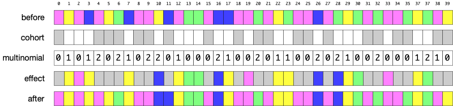

### Rule Attributes and Methods

This is the signature for the `Rule` constructor:

```
def __init__(self, *args, name= None, mechanism = None, n = None, condition = True,
                   cohort = None, actionlists = None, probs = None, update_params = False,
                   init_now = True, **kwds)
```

The following are specified attributes of Rules:

| Attribute | Explanation |
| --- | --- |
| **name** = None | If a name is not specified, then the rule is "anonymous" and will be given a unique name that begins with `anon`. |
| **mechanism**=None | The name of the mechanism to which the rule belongs. rules are "registered" with mechanisms, so if no mechanism is specified then the rule cannot be recognized, rebuilt, updated, etc. by the mechanism… |
| **n** = None | Rules operate on Columns and Cohorts of size `n`. If `n` is not specified, it may be inherited from the Rule's Mechanism. If neither `n` nor a Mechanism is specified, or if the Mechanism doesn't speci… |
| **condition=True** | A Rule will not "fire" unless `condition` is True. A condition can be a callable, in which case the applicability of a Rule can be assessed dynamically. |
| **cohort** = None | As described in [How rules work](#How-Rules-work), the actions of a rule affect only cohort members. The `cohort` argument must be a Cohort object or None or True. If None or True, a Cohort of size `n… |
| **actionlists = None** | A Rule may have one or more actionlists and each actionlist may specify one or more actions. At present, all actions assign values to Columns; for example, the tuple `(health,2)` says assign 2 to `hea… |
| **probs = None** | If a Rule has two or more actionlists then it requires a `Probs` param to assign probabilities to actionlists. |
| **update_params = False** | The Cohort and Multinomial of a Rule are generally dynamic, so require updating. But when Rules are called by simulators, and simulators may want to control which parameters. Therefore, the Rule metho… |
| **init_now = True** | See the section on [working with multiple mechanisms](#Working-with-multiple-mechanisms). |

In addition to these attributes that are specified when a Rule is created, Rules have a few other attributes:

| Attribute | Explanation |
| --- | --- |
| **initargs** | A dict containing the values of various attributes at the time the param object was created. This will probably be deprecated in future because Rules, unlike params, do not have `reset` and `rebuild` … |
| **code4callables** | If a Rule has a callable `condition`, the code is stored here. |
| **multinomial** | The multinomial attribute stores the multinomial that is created for rules with two or more actionlists |

### Rule Methods

As noted earlier, most Rules have a dynamic Cohort and a dynamic Multinomial. The question is, who is responsible for updating these params? Cohorts are updated by calling `cohort.rebuild` and Multinomials by calling `multinomial.update`. The Rule `update` method simply calls these param methods. However, it does so only if its `update_params` attribute is True, otherwise these params must be updated by another means -- usually by a simulator.

Rules have a `run_rule` method that first checks whether `condition` evaluates to `True` and, if so, applies the actions in actionlists as described in how rules work, above.

## Decisions

Viewed as probabilities, the inclinations of voters toward one candidate are determined by their inclinations toward the others. For example, if the probabilities of voting for candidates A and B are 0.2 and 0.7, respectively, then the probability of voting for C is necessarily 0.1. Thus, a choice among three candidates is represented by a point in two dimensions and a choice among two candidates by a point on a line.

Until voters vote, their points can move. Indeed, speeches and advertising and debates and other social interactions intentionally or unintentionally move points toward one or another location in the simplex. Some influences are strong; they cause points to move a significant distance toward or away from candidates. Others have barely noticeable effects. And voters themselves can be more or less resistant to influences.

Sometimes an option becomes unavailable; for example, a political candidate may drop out of the race. A three-way contest becomes two-way and probabilities of voting for the remaining candidates must be recalculated.

Voters all vote on the same day, but in general decision-makers decide at different times. For example, the decision to purchase an electric car happens continuously in populations. The number of decisions may fluctuate, there might be seasonal variation, but decisions are ongoing and continuous.

To implement this simple "theory" of population decision-making in `Mecha`, we use the `Simplex` class and the `Influence` class. A *decision space* is represented by a K-1 probability simplex in which the vertices are *options* such as political candidates and points represent the *inclinations* of members of the population. Influences move these points toward locations in the simplex. These locations are not necessarily the vertices of the simplex, they might be "intermediate" locations that have desirable properties such as being resistant to further influences.

A note on notation: A probability simplex that represents K options is called a K-1 simplex because one coordinate is determined by the remaining K-1 coordinates.

### Simplexes

The `Simplex` class is a subclass of `Param` that has all the attributes and methods described in the section on Params. The `Simplex` itself is implemented as a two-dimensional Numpy array of shape `(n,m)` where `n` is the number of members of the population and `m` is the number of options in a decision. Each row in this array contains `m` non-negative reals that sum to 1.0.

(Implementation note: One might allow any values in these rows and repeatedly re-normalize them to sum to 1.0, but the `Simplex` class methods are designed to ensure that points in the simplex stay in the simplex.)

The `Simplex` class has one special attribute called `mask`. A mask prevents some coordinates of some points from changing. Masks are boolean arrays that have the same shape as their simplexes, that is, `(n,m)`. Note that if a row in a mask contains at least `m - 1` `True` values, then it renders the associated point immobile.

#### Simplex methods -- Update

As with other params, updating the points in a `Simplex` happens only when `update_when` evaluates to `True`. The `Simplex` `update` method takes two parameters:

| Parameter | Explanation |
| --- | --- |
| **Destination** | An array of destination locations toward which points in the simplex will move. `Destination` can have the same shape as the `Simplex`, in which case each point in the `Simplex` moves toward the corre… |
| **Rate** | The distance a point moves toward its `Destination` is proportional to `Rate`. If `Rate = 0` then a point doesn't move, if `Rate = 1` then the point moves all the way to its destination. `Rate` can be… |

If some probabilities in a point are masked and we move the remaining lower-dimensional points, then their new unmasked probabilities plus those of their masked probabilities can sum to more than 1.0. To ensure that moves with masked probabilities remain in the simplex, we first rescale the unmasked probabilities, then move their points, then invert the rescaling.

#### Simplex methods -- Sample

At some point in a decision process, the decision-maker commits to one option. In the `Mecha` model of decision-making, this is done by sampling from the multinomial probabilities in the `Simplex`. For example, if many people have a 70% chance of voting for particular candidate, then the expected tally for that candidate when everyone votes is 70% of the population. Moreover, if the mean probability of voting for a candidate is `p`, then the expected tally for that candidate is `p` times the population size.

The `sample` method has two parameters:

| Parameter | Explanation |
| --- | --- |
| **index=True** | Sampling from the `Simplex` returns a vector of `n` integers that represent which option is selected. If a one-hot encoding of the selected option is preferred, specify index = False. |
| **unmasked_only=False** | A masked option might be sampled. For some models this makes sense, for others it defeats the purpose of masking. Set `unmasked_only = True` to restrict sampling to unmasked columns. |

To illustrate `Simplexes`, masking and updating, imagine a small population -- a club or association, for example -- that is considering which of three candidates to elect as their president. We can plot each club member as a point in a simplex. Here we envision the prior inclinations of 30 club members:

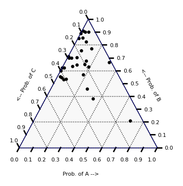

```python
from mecha.classes.utils import plot_ternary
election = Simplex(init_val = rng.dirichlet([.5,5,1.5],30))
plot_ternary(['A','B','C'],election.val,figsize=(2,2))
```

The favored candidate seems to be B, because many of the points have a strong probability of B. In contrast, no-one seems strongly inclined to vote for A. If the election were held now, B would probably win:

```python
def hold_election ():
    # sample from the points
    result = election.sample()
    # count the number of votes for each candidate
    votes =[np.sum(result == i) for i in [0,1,2]]
    print(f"candidates A,B and C get {votes} votes, respectively")

hold_election()
```

```
candidates A,B and C get [2, 20, 8] votes, respectively
```

But suppose candidate A does something to influence the election in her favor. This can be modeled as setting the destination for all points as A's corner, represented by the probability vector (1.0, 0.0, 0.0). Let's do that and then update the `Simplex`:

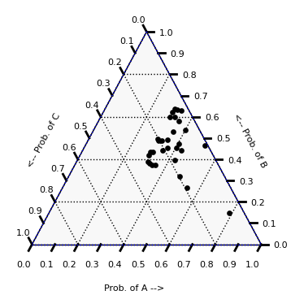

```python
A_corner = np.array([1,0,0])
election.update(destination = A_corner, rate = .3)
plot_ternary(['A','B','C'],election.val,figsize=(2,2))
```

Now the points have moved toward A's corner and the probabilities of B and C have been adjusted accordingly. If the election were held now, the results would be less clear-cut:

```python
hold_election()
```

```
candidates A,B and C get [11, 11, 8] votes, respectively
```

Now let's consider a more dynamical scenario in which, following a strong advertisement from candidate A, candidate C drops out of the race and candidate B responds with a strong advertisement of his own. The point of this example is to show that if C is no longer an option, then B's advertisement causes all the points to move in just one dimension, along the A,B axis.

We do this with masking.

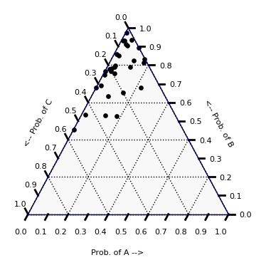

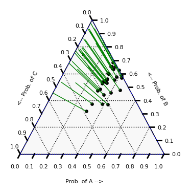

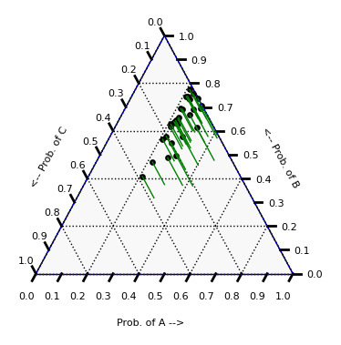

```python
# Set up the election decision simplex as before, but add a mask.
# Initially the mask is an array of False of the same shape as the
# election simplex, meaning all points are unmasked

n = 30
n_candidates = 3

election = Simplex(
    init_val = rng.dirichlet([.5,5,1.5],n),
    mask = np.zeros((n,n_candidates)).astype(bool)
)

# Show the inclinations of the electorate
plot_ternary(['A','B','C'],election.val,figsize=(2,2))

# Candidate A advertizes and moves points toward her corner
A_corner = np.array([1,0,0])
election.update(destination = A_corner, rate = .3)
plot_ternary(['A','B','C'],election.val,source_points=election.prev,figsize=(2,2))

# Candidate C drops out of the race
election.mask[:,2] = True

# Candidate B advertizes and moves points toward his corner
B_corner = np.array([0,1,0])
election.update(destination = B_corner, rate = .3)
plot_ternary(['A','B','C'],election.val,source_points=election.prev,figsize=(2,2))
```

The first simplex shows the prior inclinations of club members for candidates A, B and C. The second shows how these points move after A advertizes her candidacy. Note that the green vectors have different angles. While all the points move toward A's corner, they move in two dimensions. The last simplex shows the effect of candidate C dropping out of the race and B advertizing. The advertisement causes all the points to move toward B's corner, as expected, but the points now move parallel to the B axis. This is because the electorate can choose between only two candidates whose probabilities must sum to 1.0, so an increase in the probability of B is complemented by an identical decrease in the probability of A. If candidate A advertizes again with an even more influential message (represented by a larger rate parameter) then the points will move on exactly the same axis as above but further and in the opposite direction:

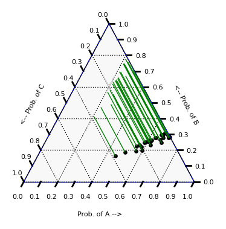

```python
# Candidate A makes an even stronger pitch (note the rate parameter).
election.update(destination = A_corner, rate = .6)
plot_ternary(['A','B','C'],election.val,source_points=election.prev,figsize=(2,2))
```

One counterintuitive aspect of this example is that even after A has advertized repeatedly and B has no chance of winning a single vote, candidate C, who dropped out of the election, will still win votes. This is because masking probabilities *locks* these probabilities, making them impervious to influences, but masking does not *clamp* these probabilities to zero. You can do this manually, but you must be very careful to renormalize the *unmasked* probabilities afterwards so that the probabilities in each point sum to 1.0.

Clamping is a complicated subject because `Mecha` allows arbitrary masks. This means that any point may have any number of its constituent probabilities masked. While this itself does not preclude masking, clamping and renormalizing points, the resulting movements of points can be difficult to understand.

That said, masking one or more dimensions in simplex and clamping their probabilities to zero is safe ground. We'll re-run the previous example but this time we'll clamp the probabilities for candidate C to zero when he drops out of the race:

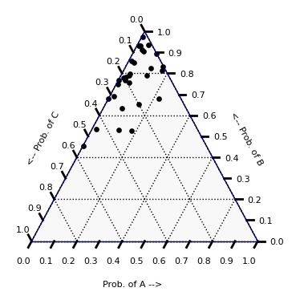

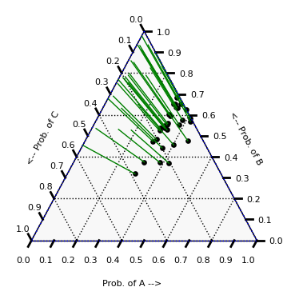

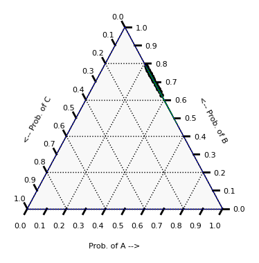

```python
election.reset()
election.mask[:] = False

# Show the inclinations of the electorate
plot_ternary(['A','B','C'],election.val,figsize=(2,2))

# Candidate A advertizes and moves points toward her corner
A_corner = np.array([1,0,0])
election.update(destination = A_corner, rate = .3)
plot_ternary(['A','B','C'],election.val,source_points=election.prev,figsize=(2,2))

# Candidate C drops out of the race

# First clamp the probabilities for candidate C to zero
election.val[:,2] = 0

# Next, mask the probabilities we've set to zero to ensure that they don't change
election.mask[:,2] = True

# Finally, renormalize only the UNMASKED values in rows so their probabilities sum to 1.0
election.val = election.row_renorm_unmasked()

# Now resume the example:  Candidate B advertizes and moves points toward his corner
B_corner = np.array([0,1,0])
election.update(destination = B_corner, rate = .3)
plot_ternary(['A','B','C'],election.val,source_points = election.prev,figsize=(2,2))
```

As expected, by clamping the probabilities of candidate C to zero, all points now lie on the axis between Prob(A) = 1 and Prob(B) == 1, such that increasing the probability of A necessarily reduces the probability of B and vice versa. If B were to run a fw more advertisements, you would see the points migrate toward B's corner:

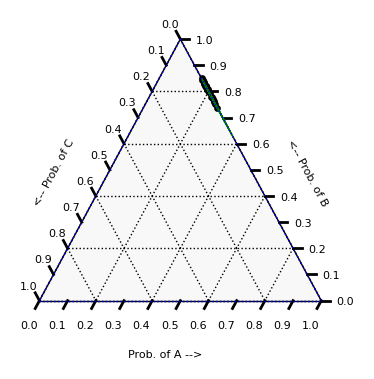

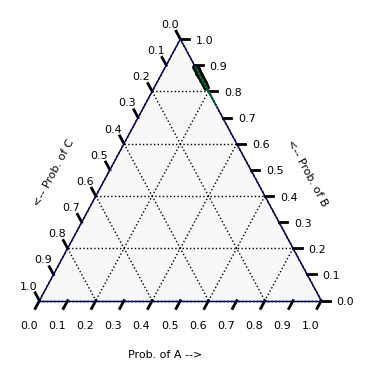

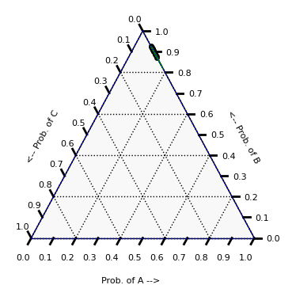

```python
for i in range(3):
    election.update(destination = B_corner, rate = .3)
    plot_ternary(['A','B','C'],election.val,source_points = election.prev,figsize=(2,2))
```

### Influences

Influences have the same attributes and methods as `Rules`. In fact, `Influence` is a subclass of `Rule` but where Rules change values in Columns, Influences change values in Simplexes. Rather than reiterate all the attributes that Influences inherit from Rules, the following describes some differences between the two.

One difference between Rules and Influences is the form of actions. The `actionlists` of Rules identify a Column and the value to which selected rows should be set. Influences instead return destinations toward which selected points in the Simplex are moved. Optionally, Influences may return a vector of rates (see simplex updating). The form of an actionlist is therefore `[ (s,d,r)* ]` where `s` is a simplex, `d` is a single destination or a 2D array of destinations, and `r` is an optional rate -- a single scalar or a vector of rates.

Like a Rule, an Influence has an optional `condition` that must be True for any action to be taken. And as with Rules, Influences operate on Cohort members, not on non-members. Influences also can have probabilistic effects, but this exposes an important difference between Rules and Influences: A Rule might stipulate that 1/3rd of the Cohort, selected at random, is affected by each of actions A,B and C. The underlying multinomial is updated and a random selection is made again *on each step* so that a Cohort member isn't "stuck" with the same action on every step. However, Influences have a kind of persistence that would be defeated by selecting a new action at each time step. For example, if a farmer is influenced to plant tomatoes on one time step, then we want the influence to continue on the next time step. There might be *competing* influences, but any given influence should "say the same thing" on each time step. To ensure this, a Influence multinomial is *not* updated on each time step.

As to `Influence` methods, there are only two: The `update` method rebuilds the Influence cohort in case it has changed. And the `run_rule` method executes the actions in the Influence actionlist in a much the same way as it does for Rules, except the actions specify destinations and rates and call the associated `Simplex.update` method with these as arguments.

The following code blocks illlustrate how Influences work. We begin by defining a Simplex and a mask.

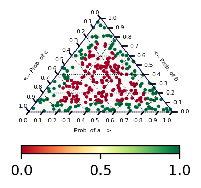

```python
from mecha.classes.rule_classes import Influence

# The following illustrates how an influence works.

n = 300
m = 3

# We'll initialize the Simplex with values from an Array, and we'll initialize
# the Array with a sample from a Dirichelet distribution.  This isn't necessary:
# we could also initialize the Simplex with an np.array.

init_probs = Array(
    init_val = rng.dirichlet(np.full(m,1),n)
    )

# We also will define a mask.  Influences cannot change masked coordinates.  If points
# have 3 dimensions, as here, then masking one coordinate means the point moves on a
# 2D shape (i.e., a line) and masking two coordinates means the point cannot move at all.
# We'll mask all the coordinates that are smaller than `small_val`.  Why? No reason, it
# was just easy to do for this example.

small_val = .1

mask = Array(
    shape=(n,m),
    init_val = init_probs.val < small_val
    )

# Now we define the simplex and plot it showing the masked (green) and unmasked (red) points

S = Simplex(
    init_val = init_probs.val,
    mask = mask.val
    )

plot_ternary(vertex_labels = ['a','b','c'], points=S.val, color_by = np.any(mask.val,axis=1),figsize=(2,2))
```

[output not shown]

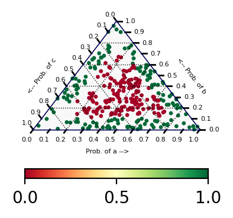

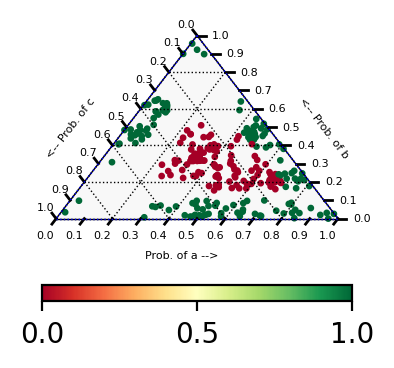

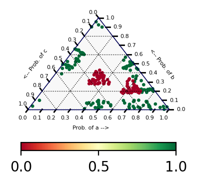

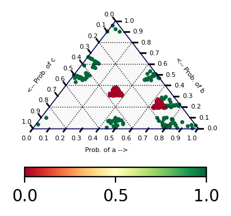

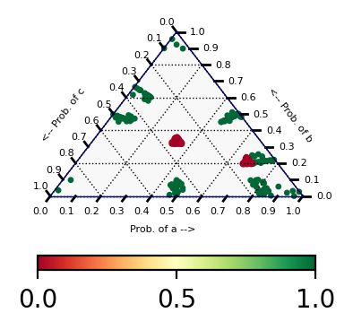

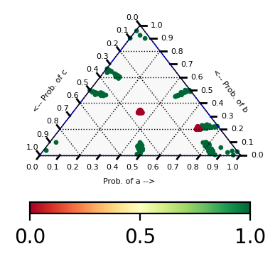

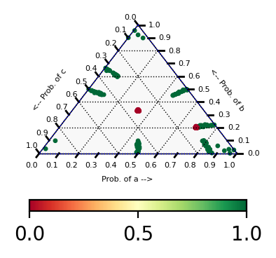

```python
print (S.n)
print (mask.val.shape)
# Each point can have its own rate. Here we define two rates, 0.1 and 0.3,
# assigned randomly to points, so some move three times faster than others.

rand = (rng.random(n) > .5)
rate = np.where(rand,.1,.3)[:,np.newaxis]

# The structure of Influences is like that of Rules.

i = Influence(
    n = S.n,
    simplex = S,
    # The influence works unconditionally:
    condition = True,
    # No cohort is specified but try saying Cohort(n = S.n, init_val = lambda self: S.val[:,0] > .2),
    cohort = True,
    # Some points move will move toward the center of the simplex, others toward "A's corner"
    actionlists = [[(S, Probs(init_val = np.array([1/3,1/3,1/3])), rate)],
                    [(S, Probs(init_val = np.array([.7,.2,.1])), rate)]
                    ],
    # Half the points will move toward the center, half toward A's corner.  These are
    # selected randomly but then the selection is NOT updated, ensuring that points
    # continue to move toward one destination on successive time steps
    probs = Probs(init_val = [.5,.5])
    )


# We'll run the influence for 40 time steps but display the simplex only every sixth
# timestep.

# Notice that the green points move along a single dimension because one dimension is
# masked, whereas the red points have three unmasked coordinates and so can move in 2D.
# The green points will "squeeze together" along one dimension and end up "pointing to"
# the red clusters! All except for the green points near each vertex.  These cannot
# move at all because they have two masked coordinates.

for x in range(40):
    i.run_rule()
    if x%6 == 0:
        plot_ternary(vertex_labels = ['a','b','c'], points=S.val,color_by = np.any(mask.val,axis=1),figsize=(2,2))
```

## Mechanisms

The `Mecha` package is intended to make it easy to build large models from smaller "nearly independent" mechanisms. `Mechanism` objects hold params and rules, updates their values, apply rules to params and so on.

Mechanisms are a subclass of Python's `SimpleNamespace` class, so one can use dot notation to access params and rules. For example:

```python
from mecha.classes.mechanism_classes import Mechanism

m = Mechanism(
    name = 'is_it_time_for_beer'
)

current_mechanism = m

clock = Cycle(
    name = 'time_of_day',
    labels = ['morning','afternoon','evening']
)

m.describe()
print()
m.time_of_day.describe()
```

```
Mechanism is_it_time_for_beer
n = None
objects =
  time_of_day:  <mecha.classes.param_classes.Cycle object at 0x7f9976ea3810>


name: time_of_day
mechanism: is_it_time_for_beer
labels: ['morning' 'afternoon' 'evening'],
current label: morning
start label: morning
update_val: None
update_when: True
kwds: {}
```

Having created a Mechanism called `is_it_time_for_beer`, we define a Cycle param called `time_of_day`. Note that we do not have to specify that `is_it_time_for_beer` is the Mechanism to which `time_of_day` belongs because we set a variable called `current_mechanism` that all Params look for if they are missing a mechanism argument.

Because `is_it_time_for_beer` is a SimpleNamespace we can access `time_of_day` as `m.time_of_day`.

Mechanisms have few attributes:

| Attribute | Explanation |
| --- | --- |
| **name** | Unlike for Params and Rules, the name of a Mechanism is not optional. |
| **n=None** | Some Mechanisms operate on populations of a given size represented by `n`. In general, if you plan to use population params like Columns, Cohorts, Simplexes and so on, you should specify `n`. Note tha… |
| **objects** | This attribute is not specified when one creates a Mechanism, but rather, when params or rules are created within a Mechanism. |
| **rules** | A list of the rules defined in a Mechanism. |

### Mechanism methods

Most Mechanism methods iterate over the Mechanism objects and run the corresponding method at th object level. For example, `Mechanism.reset` runs the `reset` method of each object.

| Method | Explanation |
| --- | --- |
| **register** | When a param or rule is created, it calls the `register` method of its parent Mechanism to register itself with the Mechanism. |
| **reset** | Runs the `reset` method of each of the Mechanism objects. Note that `Mechanism.objects` is an OrderedDict, the keys of which are the names of rules and params, the values of which are the objects, the… |
| **rebuild** | Runs the `rebuild` method of each of the Mechanism objects. |
| **update** | Runs the `update` method of each Mechanism object whose `dynamic` attribute is `True`. |
| **run_rules** | Runs the rules and influences registered with the Mechanism. Some applications might require rules and influences to apply in a random order, in which case set the `shuffle_rules` parameter to True (i… |
| **initialize** | As described in the following section, we sometimes want to delay setting the initial values of parameters. The `initialize` method initializes a Mechanism's parameters in the order in which they were… |

Lastly, `Mechanisms` register themselves with a class called `Registry`. We will see the value of `Registry` in the next section.

### Working with multiple mechanisms

Sometimes a Param or Rule in Mechanism A will depend on another in Mechanism B. If the objects for A and B are defined in a single Python module (i.e., in the same file) then no problem arises, but the point of the `Mecha` package is to allow people to develop Mechanisms independently, which probably means working in different files. Even so, one module can import another with no ill-effect.

A problem arises when there are circular dependencies between modules. Python can handle circular dependencies if the entities involved are not evaluated (e.g., if they are class definitions or function definitions). But if module A tries to evaluate something in B while module B tries to evaluate something in A, then Python will raise an error.

Because `Mechanisms` define *instances* of `Mecha` objects, the problem of circular dependencies is not uncommon. For example, we might define a module `x` that contains objects in Mechanism `m_x`, including the following, `x0`, whose initial value depends on the value of `y0` in module `y`:

[output not shown]

Module `y` might itself include an object that depends on the value of `x0`:

```
y0 = Param(
    name = 'y0',
    mechanism = m_y,
    init_val = 51,
    update_val = lambda self: x.x0.val
    )
```

If we have `x` import `y` and vice versa -- as we must, because each contains a param that depends on the other mechanism -- then Python will throw an error.

The solution begins with two observations:

1. In most cases, the problem arises when `mecha` tries to evaluate the `init_val` of a param while it is evaluating a module.
2. If modules didn't try to import each other, circular dependencies wouldn't arise.

The implemented solution works as follows:

1. All params are registered with a class called Registry
2. All params are initialized unless their `init_now` attribute is False
3. "Foreign" params are referred to as objects in the Registry
4. After all Mechanisms are imported, the params whose `init_now` attribute is False are initialized

In this scheme, the objects we just described are written this way:

```
x0 = Param(
    name = 'x0',
    init_now = False,
    init_val = lambda self: 3 * Registry.get('m_y','y0').val,
    update_val = 27
    )

y0 = Param(
    name = 'y0',
    mechanism = m_y,
    init_val = 51,
    update_val = lambda self: Registry.get('m_x','x0').val
    )
```

When both modules have been imported, `x0` can be initialized. Instead of getting the value of `y0` by importing module `y`, it is provided by the `Registry`.

The `mecha` package contains two modules called `x` and `y` with which we can demonstrate this approach. The first thing we'll do is clear out `Registry`, which has been accumulating Mechanisms throughout this Jupyter session. We'll import `x` and `y` and when both are loaded we'll initialize `x0`. Unfortunately, to make this work, we'll have to restart the Jupyter kernel and re-run this entire Jupyter session.

```python
from mecha.classes.registry import Registry

import mecha.mechanisms.x as x
import mecha.mechanisms.y as y

print(Registry.mechanisms['m_x'],'\n')
print(Registry.mechanisms['m_y'],'\n')


print(x.m_x.objects,'\n')
print(y.m_y.objects,'\n')

print(f"Value of x0 before initialization: {x.m_x.x0._val}")
print(f"Value of y0: {y.m_y.y0._val}")
x.m_x.x0.initialize_val()
print(f"Value of x0 after initialization: {x.m_x.x0._val}")
```

[output not shown]

## Simulators

You can re-rerun the code block and sometimes you will see one or more trials in which the epidemic "fizzles" in the first 50 days.